# A4-incarceration

2024-05-27

### Introduction

In the United States incarceration is a big issue, it is particularly high in the United States due to a combination of historical, legal, social, and economic factors.There so many ongoing issues that happen with incarceration such as racial inequlities, gender inequalities, and much more. In this project i plan to compare trends with male and female jail populations as well as to compare the populations with male jail population overall and to see what majority male juveniles make up in the male population. Creating this data analysis will help to understand the numbers and trends of specific categories. But most importantly, this project can help to understand policy decisions to foster public awareness.

### Summary Information

I used the “us-jail-pop.csv” dataset. It provides detailed information on jail populations across various counties in the United States, spanning multiple years. Key columns include geographic identifiers like state, and county names, demographic data such as total population and population aged 15-64, and specific jail population counts segmented by gender and race. The dataset includes information on total jail population, female and male jail populations, and further breakdowns into adult and juvenile populations. Additionally, racial categories such as AAPI, Black, Latinx, Native, White, and other races are detailed for jail populations. The urbanicity of counties is also recorded, providing a distinction between small/mid and large urban areas. While most columns have complete data, certain columns, especially those related to racial jail populations, have missing values. This dataset is valuable for analyzing trends and disparities in jail populations across different demographics and geographic locations over time.

### The Dataset

The Vera Institute of Justice is a nonprofit organization founded in 1961 to address injustices in the bail system in New York City. Its mission is to end the overcriminalization and mass incarceration of people of color, immigrants, and those experiencing poverty. Vera Institute focuses on creating evidence-based solutions to transform the criminal justice and immigration systems, ensuring they are fair and just for all.Vera’s work includes initiatives to reduce incarceration rates, promote dignity for those in detention, and advance legal representation for immigrants. They collaborate with community members, government leaders, and other stakeholders to develop and test innovative programs aimed at disrupting the current systems of incarceration. Successful pilot programs are then scaled nationwide to maximize their impact. Some implications include systemic inequalities because they highlight racial adn ethnic disparities.Another implication is the mass incarceration as their data reveals the extent of mass incarceration in the United States.By being aware of these implications the community can work towards a more just and effective criminal justice system.

### Trends Over Time Chart

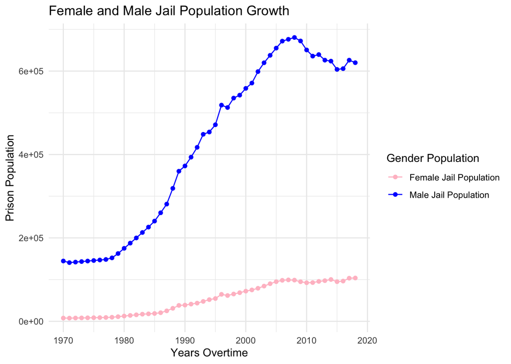

This chart shows the trends of the male jail population and female jail population. We can see that males are much more likey to be arrested than females over the years. This could be that women are generally arrested less frequently than men due to a combination of sociological, behavioral, and systemic factors.

### Variable Comparison Chart

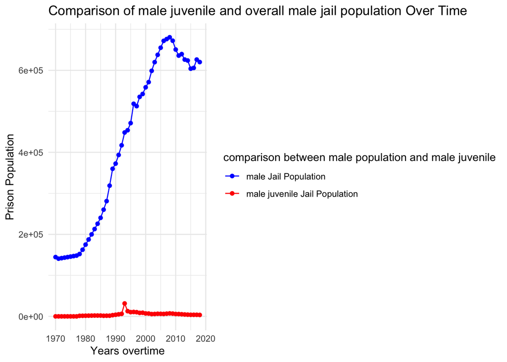

This chart compares the trends of the overall male jail population and to compare with the overall male juvenile population. I did this to see a glimpse of how much majority do male juveniles make up for the male jail population. I realized that not many juveniles make up that population. It is just a very little percentage.

### Map

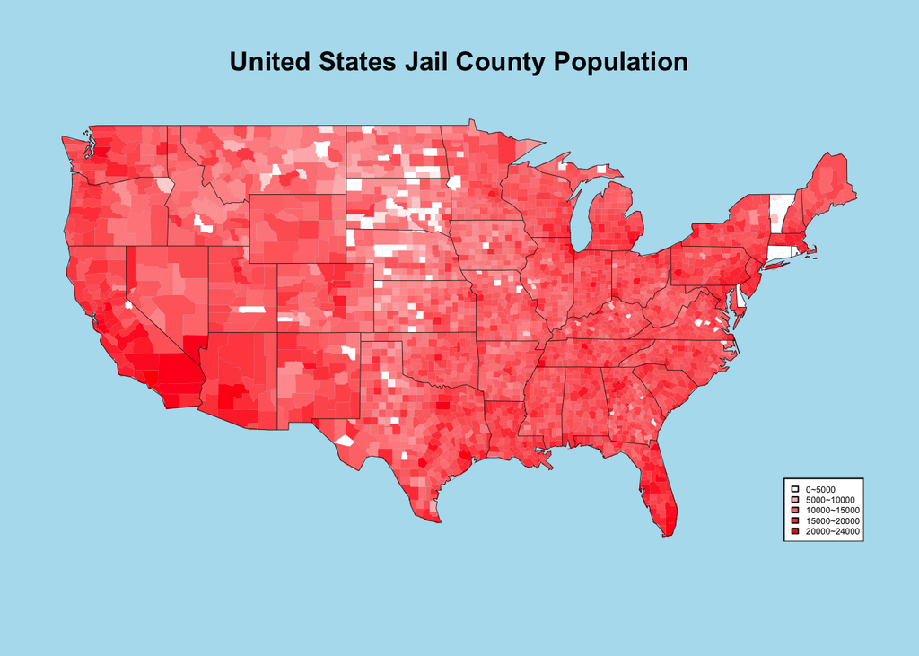

This map shows the jail population in each County’s from the United States map. I did this because when we usually talk about jails or see cop cars they go by county or cities. Especially on the news they mention for example “King County Jails”, so i found that The U.S. has a large and geographically dispersed population, making it impractical for a single, centralized system to manage all incarceration needs. County jails allow for more manageable and accessible detention facilities. Seeing the values with how many are incarcerated in each county are interesting to see the comparisions.